# The Impact of Key Players in the Twittersphere on financial markets

##### Twitter Influence Analysis

```r
library(dplyr)
library(SnowballC)
library(NLP)
library(tm)
library(RColorBrewer)
library(wordcloud)

library(jsonlite)

# get path to all files in folder
file_names <- list.files(path = "../../data/twitter - finance/", pattern = "json", full.names=TRUE)


# read in individual datasets: dynamic naming
# for (i in (1:length(file_names))) {
#   assign(x=paste("twitter_",i, sep=""),
#          value=fromJSON(file_names[i]))
# }


# read in  + combine data
data = data.frame()
for (i in file_names) {
  data = rbind(data, fromJSON(i))
}
```

# Clean Data

```r
clean_twitter_data <- function(dataset) {
    "Process each Twitter file"

    # remove redundant variables
    dataset = select(dataset, c('is_replied','is_reply_to','likes',"parent_tweet_id",
                                'screen_name',"replies", "retweets","text", 'timestamp'))

    # remove custom patterns
    dataset$text = gsub("…", "", (dataset$text))
    dataset$text = gsub("pdf", "", (dataset$text))

    # remove http (url to image)
    dataset$text = gsub('https\\S+\\s*',"", dataset$text)

    dataset[['text']] = tolower(dataset[['text']])
    dataset[['text']] = removePunctuation(dataset[['text']])
    dataset[['text']] = stripWhitespace(dataset[['text']])
    dataset[['text']] = removeNumbers(dataset[['text']])
    dataset[['text']] = removeWords(dataset[['text']], words=stopwords("en"))
    dataset[['text']] = stemDocument(dataset[['text']])


    # convert to DateTime
    dataset["timestamp"] =
      as.Date(dataset["timestamp"][1:nrow(dataset),1], format="%Y-%m-%d")

    return(dataset)
}

# clean
data = clean_twitter_data(data)


# variables
names(data)
```

```
[1] "is_replied"      "is_reply_to"     "likes"           "parent_tweet_id" "screen_name"     "replies"
[7] "retweets"        "text"            "timestamp"
```

```r
head(data$text)
```

```
[1] "great opportun metair will engag board sharehold explor best way unlock sharehold valu"
[2] "infograph jse share cannonasset"
[3] "busi maverick analysi ramaphosa wrong soe timcohen"
[4] "special report need gdp growth part via moneyweb"
[5] "special report need gdp growth part via moneyweb"
[6] "busi maverick welcom stage six load shed sa can probabl kiss gdp growth goodby"
```

# Distribution of Likes

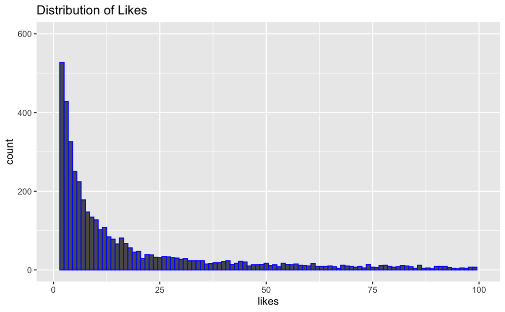

```r
library(ggplot2)
ggplot(data, aes(x=likes)) + geom_histogram(bins=100, col='blue') +
  ggtitle("Distribution of Likes") + lims(x=c(1,100), y=c(0,600))
```

```r
prop_likes_above <- function(data, thres) {
  "Compute the proportion of likes above a threshold"
  res = c()

  for (i in thres) {
    res = c(res,mean(data>i))
    print(paste("proportion of tweets with likes above", i, 'is', round(mean(data>i), digits=4)))
  }

  return(data.frame(res))
}


proportions = prop_likes_above(data$likes, seq(100,1000,100))
```

```
[1] "proportion of tweets with likes above 100 is 0.1298"
[1] "proportion of tweets with likes above 200 is 0.098"
[1] "proportion of tweets with likes above 300 is 0.0793"
[1] "proportion of tweets with likes above 400 is 0.067"
[1] "proportion of tweets with likes above 500 is 0.06"
[1] "proportion of tweets with likes above 600 is 0.0532"
[1] "proportion of tweets with likes above 700 is 0.0481"
[1] "proportion of tweets with likes above 800 is 0.0442"
[1] "proportion of tweets with likes above 900 is 0.0409"
[1] "proportion of tweets with likes above 1000 is 0.0382"
```

# Understand the Data

Are the number of retweets heavily skewed towards certain users?

- How many tweets do we see per user?
- How many average retweets do we see per user?
- How do these two frequencies relate?

```r
paste("Number of Unique Accounts Tweeting: ", length(unique(data$screen_name)))
```

```
[1] "Number of Unique Accounts Tweeting:  2548"
```

```r
# mean retweets per user & tweets per account
agg_tweets = data %>% select(screen_name, retweets) %>%
  group_by(screen_name) %>% summarise(mean_retweets = round(mean(retweets)),
                                      appearances = table(screen_name),
                                      n = n()) # same as appearences


head(agg_tweets)
```

| screen_name | mean_retweets | appearances | n |
| --- | --- | --- | --- |
| __waza | 0 | 1 | 1 |
| _AfricanSoil | 0 | 2 | 2 |
| _bluaura | 0 | 1 | 1 |
| _bongiwelanga | 0 | 2 | 2 |
| _butiMo | 0 | 2 | 2 |
| _DJCappuccino | 476 | 1 | 1 |

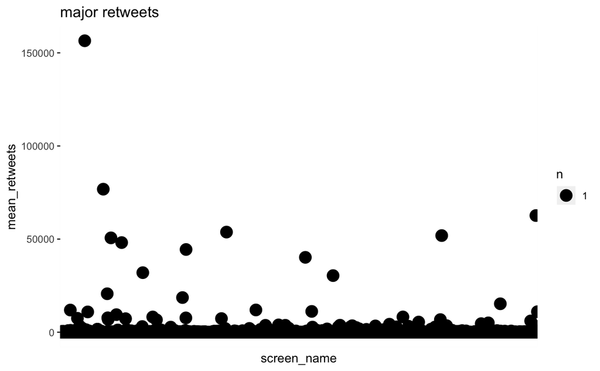

```r
ggplot(agg_tweets, aes(x=screen_name, y=mean_retweets)) + geom_count() +
  ggtitle("major retweets") +
  theme(axis.text.x=element_blank(),
        axis.ticks.x=element_blank())
```

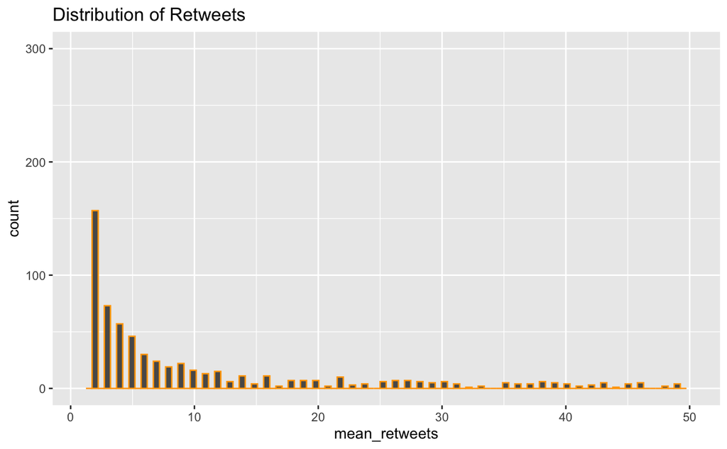

```r
ggplot(agg_tweets, aes(x=mean_retweets)) + geom_histogram(bins=100, col='orange') +
  ggtitle("Distribution of Retweets") + lims(x=c(1,50), y=c(0,300))
```

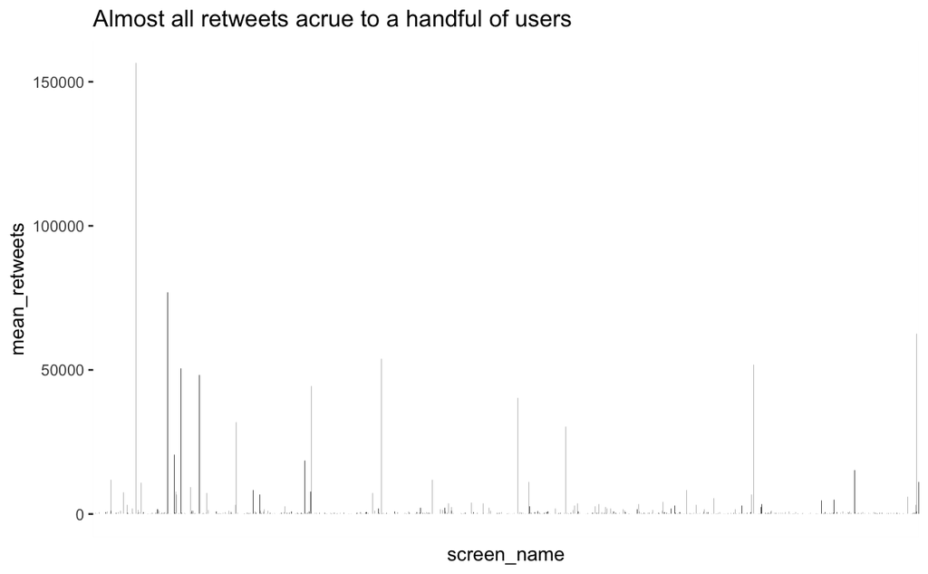

```r
ggplot(agg_tweets, aes(x=screen_name, y=mean_retweets)) + geom_bar(stat="identity") +
  theme(axis.text.x=element_blank(), axis.ticks.x=element_blank()) +
  ggtitle("Almost all retweets acrue to a handful of users")
```

```r
NA
NA
```

It then, may be possible to *weight* users tweets based on their:

- Average Retweets
- Number of Tweets
- Interaction: Average Retweets x Number of Tweets

To more accuractly model the sentiment of the public by expressing sentiment as a weighted function of influencial players in the Twittersphere.

Other possible variable distinctions:

- own tweet vs retweet influence
- replies

# Corpus EDA

```r
library(plotly)
library(RSentiment)
library(stringr)
library(broom)
library(tidyr)
library(tidytext)
library(NLP)

library(tm)
library(wordcloud)
library(SnowballC)

# proportions
head(prop.table(agg_tweets$mean_retweets),10)
```

```
 [1] 0.000000e+00 0.000000e+00 0.000000e+00 0.000000e+00 0.000000e+00 4.347095e-04 9.132554e-07 9.132554e-07
 [9] 0.000000e+00 0.000000e+00
```

```r
head(prop.table(agg_tweets$n), 10)
```

```
 [1] 7.982757e-05 1.596551e-04 7.982757e-05 1.596551e-04 1.596551e-04 7.982757e-05 7.982757e-05 7.982757e-05
 [9] 7.982757e-05 7.982757e-05
```

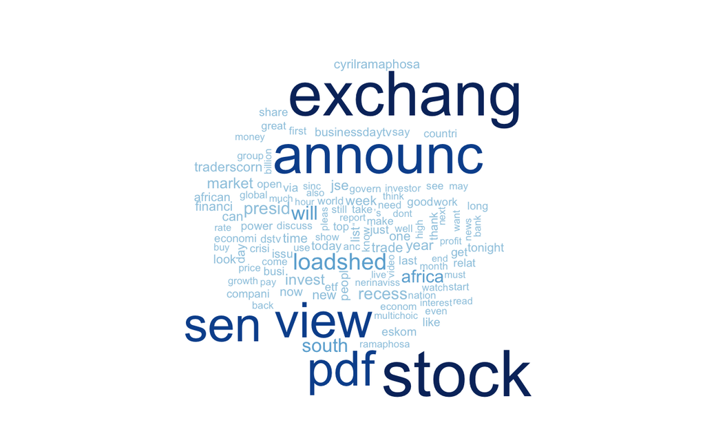

```r
library(tinytex)




prepare_for_NLP <- function(text_data) {
  "Prepare Corpus for NLP"
  corpus <- Corpus(VectorSource(text_data))      # create corpus
  myDtm <- DocumentTermMatrix(corpus)           # doc x term matrix

  # reduce sparsity
  sparse = removeSparseTerms(myDtm, sparse=.99)
  sparse = as.data.frame(as.matrix(sparse))
  # colnames(sparse) = make.names(colnames(sparse))

  # freq of words
  frequency_of_words = colSums(sparse)
  frequency_of_words = frequency_of_words[order(frequency_of_words, decreasing=T)]

  # arrange from most
  #print("Most frequently occuring words:")
  #print(head(frequency_of_words, 7))

  # create wordcloud
  wordcloud(freq=as.vector(frequency_of_words), words=names(frequency_of_words),
          colors=brewer.pal(9, "Blues")[4:9])

  # store results
  res = list()
  res$myDtm = myDtm
  res$frequency_of_words = frequency_of_words
  rescorpus = corpus
  res$sparse = sparse

  return(res)

}


res = prepare_for_NLP(data$text)
```

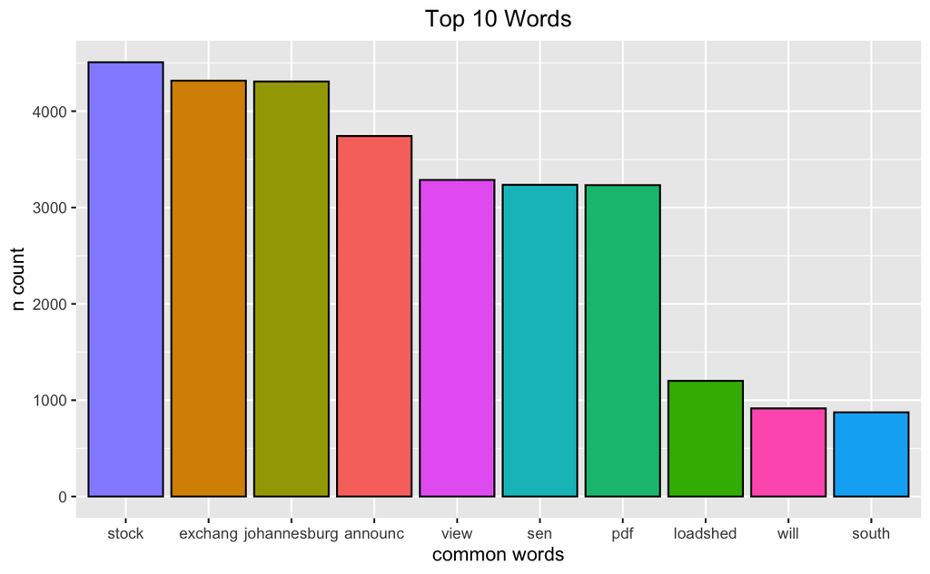

```r
# visualize most freq words
vis = data.frame(word=names(res$frequency_of_words),
                 freq=as.vector(res$frequency_of_words))

ggplot(vis[1:10,], aes(x=reorder(word, -freq), y=freq, fill=word)) +
  geom_bar(col="black", stat="identity") + xlab("common words") + ylab("n count") +
  ggtitle("Top 10 Words") + guides(fill=F) + theme(plot.title=element_text(hjust=0.5))
```

```r
# find associated words: great feature of search
print('words associated with "good"')
```

```
[1] "words associated with \"good\""
```

```r
findAssocs(res$myDtm, c('good'), 0.12)
```

```
$good
    news   brand”     leon      “da  anywayz      mmm     nich     luck distinct    glori    embed
    0.17     0.17     0.17     0.17     0.16     0.16     0.16     0.14     0.13     0.13     0.12
```

```r
# Cluster the data


# k means clustering
# d = dist(t(as.matrix(myDtm)), method='euclidean')
# kfit = kmeans(d, 3)
# summary(kfit)
# head(kfit)
```